# Using Rcaline: An Illustrated Example

2014-11-07

# Introduction

Here we apply `Rcaline` to San Francisco data provided by the [Bay Area Air Quality Management District](http://www.baaqmd.gov) (BAAQMD). This vignette illustrates the basic steps of constructing, running, and visualizing a model with `Rcaline`. We discuss how to load, visualize, and export model data with the use of several third-party packages.

# Model construction

## Traffic data

Example traffic data has been supplied for you in the form of a `SpatialLinesDataFrame` called `SF_highways`.

```
## Object of class SpatialLines
## Coordinates:
##       min     max
## x  543798  558957
## y 4167305 4187433
## Is projected: TRUE
## proj4string :
## [+proj=utm +zone=10 +datum=NAD83 +units=m +no_defs +ellps=GRS80
## +towgs84=0,0,0]
```

```
## 'data.frame':    125 obs. of  13 variables:
##  $ STI_ID    : int  0 8 10 35 46 47 48 49 50 51 ...
##  $ LRSKEY_STI: Factor w/ 81 levels "000000000101041",..: 2 67 41 67 18 19 68 18 19 18 ...
##  $ LRSSEQ_STI: int  4 20 10 14 3 17 24 1 18 2 ...
##  $ County_FIP: int  75 75 75 75 75 81 81 75 81 75 ...
##  $ SRNum     : Factor w/ 47 levels "SR-1","SR-101",..: 1 28 2 28 30 30 28 30 30 30 ...
##  $ LaneNum   : int  6 8 8 8 6 5 8 4 4 6 ...
##  $ AltName   : Factor w/ 148 levels "19TH AVE","6TH ST",..: 1 NA 44 107 102 101 NA 101 101 102 ...
##  $ Vol2009   : num  81000 87000 232000 158000 24150 ...
##  $ TRVol2009 : num  1377 1392 5986 2623 251 ...
##  $ BEGMP     : num  1.89 5.38 2.65 3.33 2.11 ...
##  $ ENDMP     : num  4.02 5.67 2.99 3.87 3.16 ...
##  $ MILES     : num  2.243 0.311 0.356 0.517 0.981 ...
##  $ SPDBinID  : int  5 11 10 11 5 6 11 6 6 5 ...
```

It was originally imported from a shapefile. Should you have traffic data of your own in shapefile format, you can use `readOGR()` from the `rgdal` package to import it. The next section will describe how to set it up for use in your model.

> See `help(readOGR, package = "rgdal")` and `help(SpatialLinesDataFrame, package = "sp")` for more on these data structures and their applications.

## Meteorological data

Another example input comes in the form of an ASCII file, `met_5801.isc`, that contains $24 \times 365 = 8760$ records containing a year’s worth of data on:

- wind speed (m/s)
- wind bearing (degrees)
- atmospheric stability (Pasquill A-F)
- mixing height (meters)

… at 1-hour scale.

```
##    windSpeed      windBearing  stabilityClass  mixingHeight
##  Min.   : 0.00   Min.   :  0   Min.   :1.00   Min.   :300
##  1st Qu.: 1.83   1st Qu.:183   1st Qu.:3.00   1st Qu.:300
##  Median : 3.08   Median :255   Median :4.00   Median :300
##  Mean   : 3.31   Mean   :222   Mean   :4.01   Mean   :300
##  3rd Qu.: 4.52   3rd Qu.:269   3rd Qu.:5.00   3rd Qu.:300
##  Max.   :11.27   Max.   :360   Max.   :6.00   Max.   :300
```

## Emission data

`CALINE3` models dispersion at the level of individual links, so `Rcaline` splits each polyline into individual segments, assigning to each segment the attributes of the polyline to which it belonged.

> In California, pollutant-specific emission factors can be obtained from [EMFAC](http://www.arb.ca.gov/msei/modeling.htm).

## Receptor locations

*Receptors* are the locations at which the dispersed pollutant concentration will be calculated. Since `CALINE3` is a steady-state Gaussian plume model, rather than a numerical grid-based model, the locations of receptors can be freely specified.

Here we show how to generate receptors on a regular Cartesian grid within 1 km of highway centerlines:

However, relying on a Cartesian grid can result in apparent “hot spots” that are just the result of certain grid points falling very close to links.

An alternative approach is to generate receptor locations at regular distances from the road network. This approach also allows receptors to be packed more densely close to the roadway, so that modeling resources can be concentrated on the more interesting locations (i.e., those closer to the roadways).

[figure not shown]

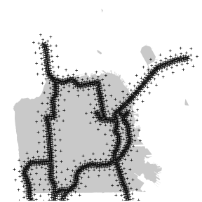

If you were interested in estimating aggregate exposures at a population level, you could also construct an irregular grid by sampling locations from predefined regions, like ZIP codes or census tracts.

## Terrain and pollutant properties

For detailed information on terrain and pollutant characteristics, consult the [CALINE3 User’s Guide](http://www.epa.gov/scram001/dispersion_prefrec.htm). Here we specify some reasonable default values:

```
## $name
## [1] "PM2.5"
##
## $molecularWeight
## [1] NA
##
## $settlingVelocity
## [1] 0
##
## $depositionVelocity
## [1] 0
##
## attr(,"class")
## [1] "Pollutant"
```

# Predicting concentrations

The CALINE3 algorithm is CPU-intensive. Although it is beyond the scope of this example, you can use the `foreach` package to do computations in parallel, using multiple cores or networked hosts. (A future vignette will illustrate this technique.)

## Running the model

We use the `predict` method to actually run the model. Since the model will actually be run once for every meteorological condition we supply ($n = 8760$), it can be helpful to make a first pass using only a small sample of the meteorology.

The result of running the model is an $M \times N$ `HourlyConcentrations` matrix, where $M$ is the number of meteorological conditions and $N$ is the number of receptors. Each cell describes the predicted concentration at that receptor during those conditions.

## Summarizing results

The `aggregate.HourlyConcentrations` helper function will compute several statistics by default, including the mean and maximum.

```
## [1] "min"    "mean"   "median" "GM"     "max"    "sd"
```

Casting the resulting `AggregatedConcentrations` object to a `SpatialPointsDataFrame` then re-binds the statistics to the receptor locations.

```
##                    coordinates distance  min mean median  max
## RECP. 1 (544000, 4170000, 1.8)      100 7.64 7.64   7.64 7.64
## RECP. 2 (544000, 4170000, 1.8)      100 7.44 7.44   7.44 7.44
## RECP. 3 (544000, 4170000, 1.8)      100 7.36 7.36   7.36 7.36
```

Afterwards, we can select a statistic of interest and explore the distribution. Here we focus on exploring results graphically, although they could also be tabulated or subjected to statistical tests.

## Distance-to-roadway

Within the results is a variable, `distance`, that describes the distance-to-roadway for each receptor. (Recall that we specified these distances when constructing the receptor grid.) Using this, we can group the receptors into specific classes and explore the distribution of predicted concentrations in each.

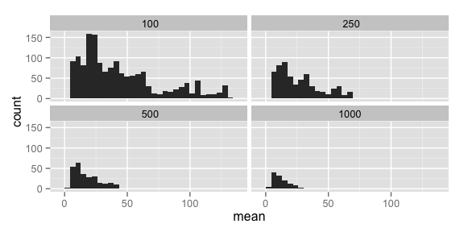

Distributions of the mean predicted concentration, by distance-to-roadway.

## Mapping

`Rcaline` provides a helper function `ggplot.AggregatedConcentrations` that automates the re-binding of predicted concentrations with receptor locations, as well as the plotting of model inputs such as receptors and links. Here is an example of a “bubble” plot generated with `ggplot.AggregatedConcentrations`:

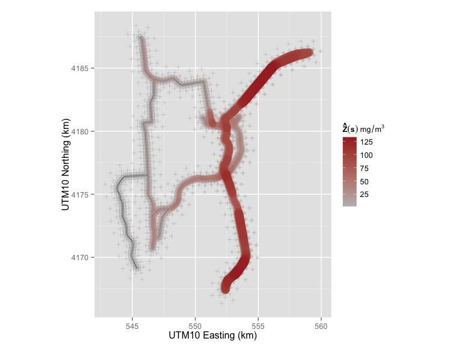